# Confusion Matrix Explanation Using Stock Data

Ron Guymon

2022-12-02

# How To Use Confusion Matrices

Confusion matrices are…confusing. One reason why confusion matrices are confusing is because there are a lot of terms to describe the same thing. I hope this demonstration helps identify why accuracy alone should not be the main metric for evaluating which model to use.

Let’s create a couple of models for estimating whether Amazon’s stock price will increase between the next day and three days later. An increase in the stock prices is coded as 1 (up), while a decrease is coded as zero (down). Since the focus of this is not on modeling, I will hide the code chunks for:

- Gathering the data for AMZN using the quantmod package.
- Data wrangling to create new columns based on technical indicators.
- Data preprocessing to split the data into training and testing data.
- Creating a model using logistic regression, and another model using recursive partitioning (decision trees).
- Making predictions with the model.

Below are the confusion matrices and the metrics associated with each model.

# Confusion Matrices

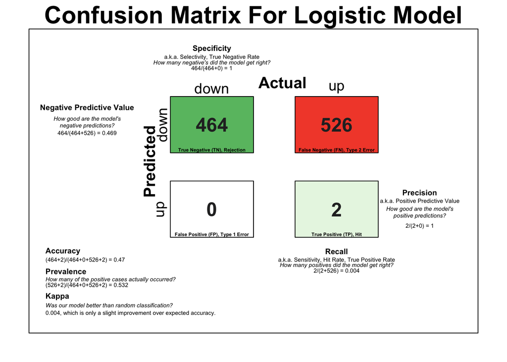

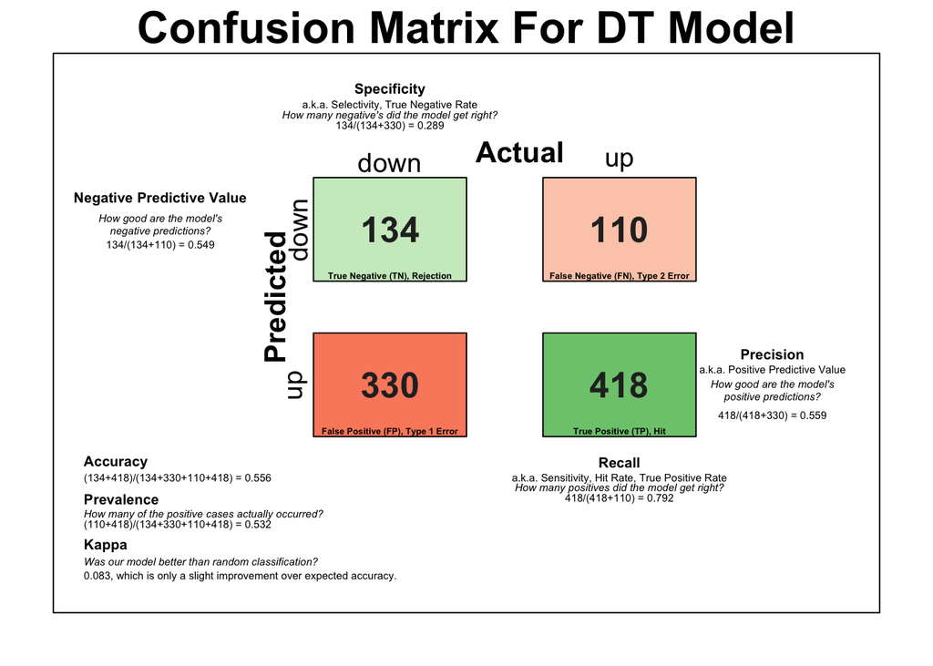

# Comparison and Discussion

The logistic regression (LR) model has an accuracy of only 47%, while the decision tree (DT) model has an accuracy of 55.6%. While neither model is very accurate, the DT model is substantially more accurate than the LR model.

Let’s suppose that you really want to avoid drawdowns. In other words, you have a strong preference that your account balance never decreases. You will probably be more interested in the *precision*, or *positive predictive value*, metric. In other words, you don’t want to make wrong predictions. The LR model’s precision is perfect, 100%. (You rarely make investments with that model, but when you do you can be very confident in them.) Thus, even though the DT model has a higher accuracy, the LR model would be preferred.

If you are short selling, and hoping to make a profit from a decrease in stock price, then you will probably be more interested in the *negative predictive value* metric. Because the DT model has a higher negative predictive value of 54.9% relative to 46.9% for the LR model, you would probably prefer the decision tree model.

# Mnemonics for Remembering Some Terms

I often focus on precision and recall, which are associated with the positives, or in this case, the ups. Here’s one way to remember those terms:

- First, **Re** call deals with how effectively you are able to accurately classify **Re** al positives
- Second, **Pre** cision deals with how often your **Pre** dictions about positives are correct.

I feel like we need a song, rap, skit, or something else to help us remember all of the other terms. Let me know if you make one!